# Plots and further analyis from output of PhyloAcc

### Expected number of independent accelerations and accelerated species per element

Next, we compute the expected number of independent accelerations and accelerated species within target species. We will first select all the ratite-accelerated elements (in this simulation, all elements are ratite accelerated and expectedly, the algorithm selects almost all the simulated elements), and then compute and get the histogram of expected number of independent accelerations within clades of target species as well as accelerated target species for each element.

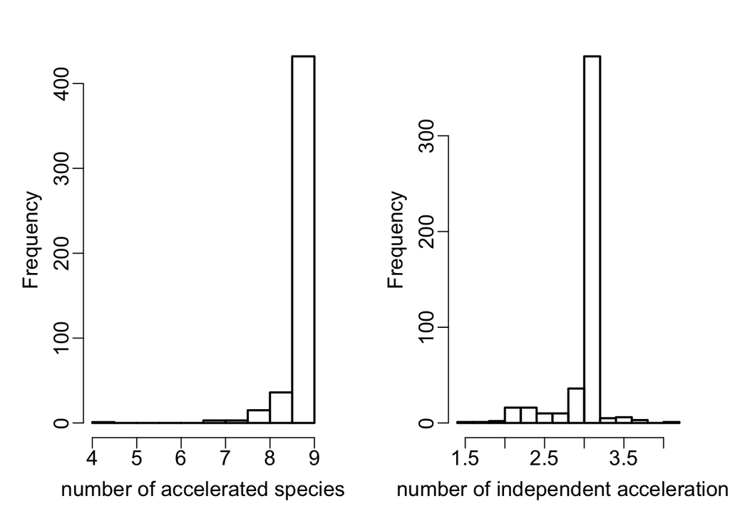

```r
sel <- score$No.[which(score$logBF1>10 & score$logBF2 > 1)] # select the ratites accelerated elements
internal <- getInternals(treeData$tree, targets) # get common ancestors of target species that might be accelerated
topZ = postZ[postZ$No. %in% sel, seq(10, ncol(postZ), by=4)] # get the posterior of Z==2 (being accelerated) for selected elements
colnames(topZ) <- sapply(colnames(topZ), function(x) strsplit(x, "_")[[1]][1])

acc = rowSums(topZ[,targets]); # expected number of accelerated species within target species
loss = rowSums(topZ[,targets]) - rowSums(topZ[,internal]) # expected independent accelerations occurred
par(mfrow=c(1,2), mar=c(4, 4, 2, 2), mgp = c(2, .5, 0),cex.lab = 1.2,cex.axis=1.2,lwd=2)
hist(acc, main="", xlab ="number of accelerated species"  );
hist(loss, main="", xlab= "number of independent accelerations")
```

The simulated configuration is that all ratites branches are accelerated, so there are three independent losses (i.e. one at the ancestor of kiwi-Rhea clades, one for Moa and one for Ostrich) and all 9 target species are accelerated. The histogram shows that the model correctly identifies 3 losses and 9 accelerated branches within ratites. For real data which contains different acceleration patterns, these distributions will be more flat. To get elements that might be associated with phenotypically convergence, we could select elements with multiple independent accelerations and/or accelerated in most target species.

### Evolutionary patterns over all elements

Finally, we can get the overall posterior probability of acceleration on each branch for all the input elements. The higher means that branch is more likely to be accelerated across the whole genome (or all inputs).

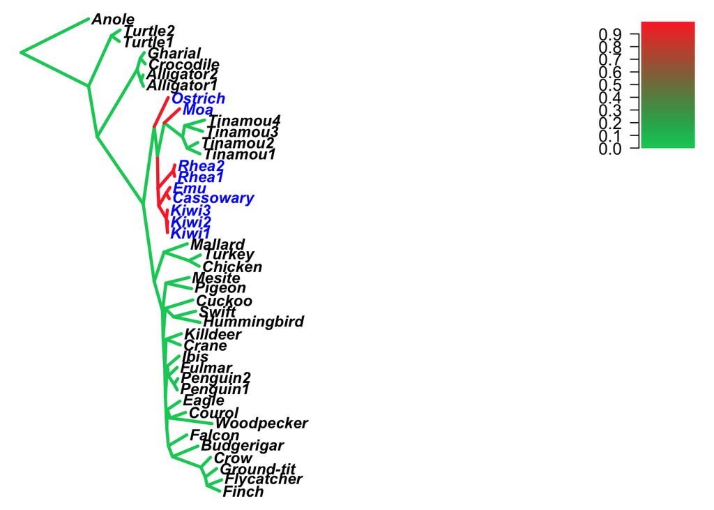

```r
plotZPost_all(treeData, topZ, targets) # treeData is from first step; topZ are ratite-accelerated elements selected in the previous section; targets are target species (here, ratites)
```

In this example, all input elements are accelerated only in ratite branches, and our model detected the pattern correctly as the average acceleration probability is nearly 1 for ratites (shown as red) but it is nearly 0 for non accelerated branches. But for the real data, since all patterns are mixed together, the average posterior probability of acceleration will not be concentrated at 1.